# What does affect the trip duration?

## by: Ahmed Magdy Abdelhaseib Mohamed

## Investigation Overview

In this investigation, I wanted to look at if the rider and trip informations that could be used to predict the trip duration. i focused on these features: distance, user type, member gender, day of week, member birth year.

## Dataset Overview

There are 170839 trips in this dataset with 18 features('duration_sec', 'start_time', 'end_time', 'start_station_id', 'start_station_name', 'start_station_latitude','start_station_longitude', 'end_station_id', 'end_station_name', 'end_station_latitude', 'end_station_longitude', 'bike_id', 'user_type','member_birth_year', 'member_gender', 'bike_share_for_all_trip','distance_Km', 'day_of_week') these trips happened in the period between febreuary and march in 2019. There were some missing values, trips with distances equal 0 and some illogical values in the `member_birth_year` like (1878, 1910, 1920,....etc) so, i removed all these values.

## Distribution of Trips Durations

Duration has a very larg range of values starts from 61 sec to 84548 sec,with most of the trips have low durations and only few trips have high durations. when plotted on log-scale the distribution of the duration looks unimodal and its peak at 500 seconds. There are some outliers for points greater than 10k seconds.

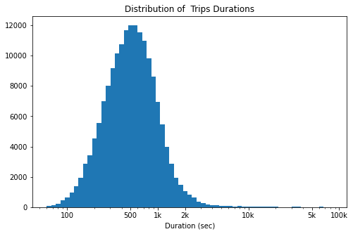

## Distribution of Trips Distances

Distance also has a very larg range of values starts from 0.01 Km to 70 Km ,with most of the trips distances are between 0.3 & 4 Km. when plotted on log-scale the distribution of the duration looks unimodal and its peak below 2 Km. There are some outliers for points greater than 10 km.

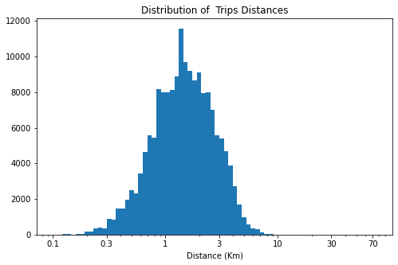

## Distribution of riders birth year

Most of the riders were born in eighties or nineties and a few of them were born fifties, sixties and seventies.

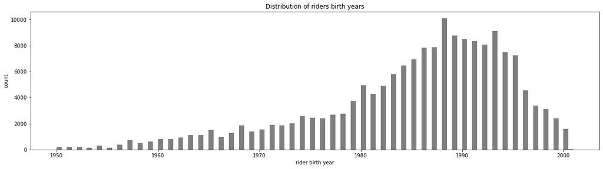

## Distribution of Trips over the weekdays

The lowest number of trips is in the weekend while in other days it is larger. Thursday is the most crowded day and Tuesday come in the second order.

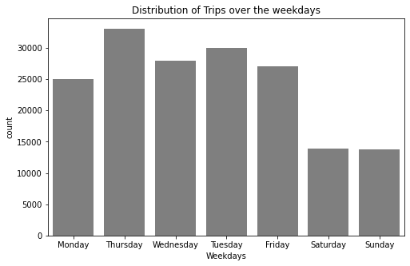

## Duration vs. Trip Distance

Plotting duration and distance on a logarithmic scale produces an approximately linear relationship. when we take limits to x-axis to looke deeperly to the crowded region, we can see that the cloud of points is close to the bottom right than the upper life which means that the variation on the duration axis is smaller than the distance axis.

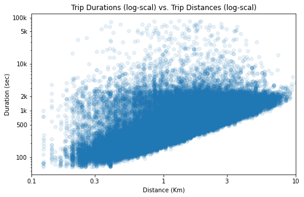

## Duration and distance by User Type

The median of the duration for subscribers is less than customers although the difference in distance median is very small so, here we can say that in average subscribers have small durations than customers for the smae trip distance. therefore this is a clear evident that the riders informations have an interaction with the trip duration and distance.

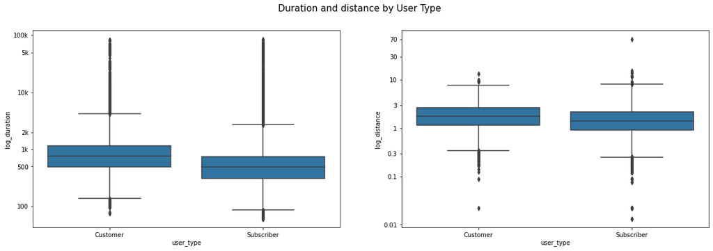

## Duration and distance by User Type & Weekdays

Then, after all it is clear now that these categorical variables have a strong effect on the duration of the trip regardless its distance.

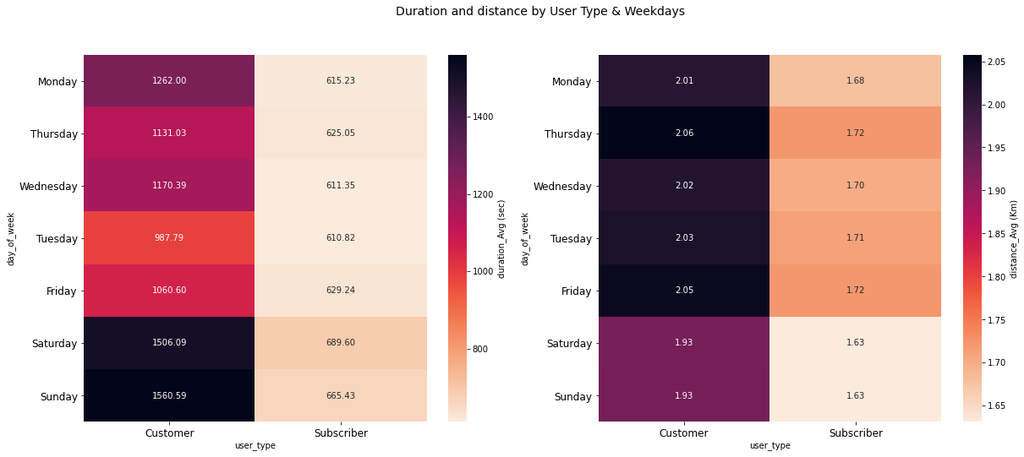

## Duration and distance by riders gender & Weekdays

Reproducing the same plots with member gender instead of user type shows the interaction between the rider gender and the trip duration and distance where males have the lowest average duration and distance and "other" gender has the highest.

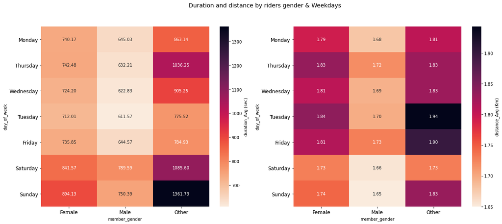